# Benchmarking NA12878 SVs by different callers

Jan 12, 2022

# Version updates

**3rd edition**

- Included SvABA outputs, well-processed and included relevant R scripts;
- *NB: We discourage the use of benchmark.master and benchmark.bed files included in this R notebook.* Please use the maestro file instead as included in the maestro_generation.R script.
- Need to proofread codes on the generation of benchmark.annot used in this edition.
- (continued) Might move relevant codes to new notebook instead, and use the maestro file for all analyses.

```r
rm(benchmark.master)
```

# Introduction

See ReadME.md.

Filtering and processing notes:

```
1) FILTER == "PASS"
2) We will try to include supporting reads info on the 2nd edition workflow;
3) Currently awaiting gold standard NA12878 SV call set ("truth set")
4) Will aim to expand "call match" criteria: Specifically,
```

In the first edition, we used “Start = Start && end = end” as the criteria for matching SV calls;

This appeared too strict, as many calls do not have multiple callers reported.

We will change this criterion to:

```
    Start <belongs to> [Start_std +- CI%] && end <belongs to> [End_std +- CI%]
```

# 1. Data loading and processing: Benchmark.master

See R script “maestro_generation” to generate a fully-annotated “maestro” file containing annotated VCF @fix columns from NA12878 and its two subsets, small and medium NA12878.

```r
library(tidyverse)
library(vcfR)
library(GenomicRanges)
```

```r
delly.vcf <- read.vcfR("NA12878.delly.vcf")
```

[output not shown]

```r
manta.vcf <- read.vcfR("NA12878.manta.vcf")
```

[output not shown]

```r
melt.vcf <- read.vcfR("NA12878.melt.vcf")
```

[output not shown]

```r
wham.vcf <- read.vcfR("NA12878.wham.vcf")
```

[output not shown]

```r
svaba.vcf <- read.vcfR("NA12878.svaba.vcf")
```

[output not shown]

```r
# filtering only PASS SVs
as.data.frame(getFIX(delly.vcf)) %>%
  filter(FILTER == "PASS") -> delly.pass
as.data.frame(getFIX(manta.vcf)) %>%
  filter(FILTER == "PASS") -> manta.pass
as.data.frame(getFIX(melt.vcf)) %>%
  filter(FILTER == "PASS") -> melt.pass
as.data.frame(getFIX(wham.vcf)) %>%
  filter(FILTER == "PASS") -> wham.pass
as.data.frame(getFIX(svaba.vcf)) %>%
  filter(FILTER == "PASS") -> svaba.pass
```

```r
# assigning respective callers
delly.pass$Caller <- "Delly"
manta.pass$Caller <- "Manta"
melt.pass$Caller <- "Melt"
wham.pass$Caller <- "Wham"
svaba.pass$Caller <- "SvABA"

# synthesise the filtered data frames into one master file
library(plyr)

join(delly.pass, manta.pass, type = "full") %>%
 join(melt.pass, type = "full") %>%
  join(wham.pass, type = "full") %>%
    join(svaba.pass, type = "full") -> benchmark.master

# untick plyr afterwards to avoid conflict with dplyr
detach("package:plyr", unload = TRUE)
rm("delly.pass")
rm("manta.pass")
rm("melt.pass")
rm("wham.pass")
rm("svaba.pass")
```

# 2. Annotation (For vcfR objects only; skip to 2-2 if using AnnotSV outputs)

As expected, the “ALT” column contains not only SV_type info for larger variants, but also the entire variant description if “fillable” inside the cell…

This is problematic and for any meaningful analysis to be carried out, we need to annotate the file.

## 2-1. Benchmark.bed (Pseudo-BED file using a PapenfussLab workflow)

```r
# From Papenfuss lab
# https://github.com/PapenfussLab/gridss/blob/master/example/somatic-fusion-gene-candidates.R
#
# Very basic example R script that demonstrates
# how GRIDSS output can be combined with the
# StructuralVariantAnnotation package and BioConductor
# to perform useful analyses.
#
# This script performs a very basic check for somatic
# gene fusions that could result in a fusion transcript
# It does not check that the transcript in in-frame, nor
# does it check that the resultant fusion actually involves
# one or more exons from each gene.
#
# CRAN packages
library(devtools)
library(stringr)

# bioconductor packages
library(VariantAnnotation)
library(GenomicRanges)
library(GenomicFeatures)
library(rtracklayer)
library(StructuralVariantAnnotation) # install_github("d-cameron/StructuralVariantAnnotation")
```

```r
# Simple SV type classifier
simpleEventType <- function(gr) {
  pgr = partner(gr)
  return(ifelse(seqnames(gr) != seqnames(pgr), "CTX", # inter-chromosomosal
    ifelse(strand(gr) == strand(pgr), "INV",
      ifelse(gr$insLen >= abs(gr$svLen) * 0.7, "INS", # TODO: improve classification of complex events
        ifelse(xor(start(gr) < start(pgr), strand(gr) == "-"), "DEL",
          "DUP")))))
}
```

```r
# using manta calls as example

vcf <- readVcf("NA12878.wham.vcf") ## replace VCF input manually to generate respective files

info(header(vcf)) = unique(as(rbind(as.data.frame(info(header(vcf))), data.frame(
    row.names=c("SIMPLE_TYPE"),
    Number=c("1"),
    Type=c("String"),
    Description=c("Simple event type annotation based purely on breakend position and orientation."))), "DataFrame"))
gr <- breakpointRanges(vcf)
svtype <- simpleEventType(gr)
info(vcf)$SIMPLE_TYPE <- NA_character_
info(vcf[gr$sourceId])$SIMPLE_TYPE <- svtype
info(vcf[gr$sourceId])$SVLEN <- gr$svLen ## svLen == "svLeng" and stores the length of the SVs
writeVcf(vcf, "NA12878.wham.annot.vcf")

# TODO: perform event filtering here
# By default, GRIDSS is very sensitive but this comes at the cost of a high false discovery rate
gr <- gr[gr$FILTER == "PASS" & partner(gr)$FILTER == "PASS"] # Remove low confidence calls

simplegr <- gr[simpleEventType(gr) %in% c("INS", "INV", "DEL", "DUP")]
simplebed <- data.frame(
    chrom=seqnames(simplegr),
    # call the centre of the homology/inexact interval
    start=as.integer((start(simplegr) + end(simplegr)) / 2),
    end=as.integer((start(partner(simplegr)) + end(partner(simplegr))) / 2),
    name=simpleEventType(simplegr),
    score=simplegr$QUAL,
    strand="."
)
# Just the lower of the two breakends so we don't output everything twice
simplebed <- simplebed[simplebed$start < simplebed$end,]
# write.table(simplebed, "caller.simple.bed", quote=FALSE, sep='\t', row.names=FALSE, col.names=FALSE)
```

```r
str(simplebed)
```

```r
table(simplebed$name)
```

Now, assign simplebed (eqv? annot.tsv) to each caller and remove/repeat:

```r
# copy df
delly.bed <- data.frame(simplebed) ## use CallerName.bed
```

```r
# clean-up
rm(vcf)
rm(gr)
rm(simplegr)
rm(simplebed)
```

Now we can synthesise the simplebed files from each caller:

```r
# assigning respective callers
delly.bed$Caller <- "Delly"
manta.bed$Caller <- "Manta"
melt.bed$Caller <- "Melt"
wham.bed$Caller <- "Wham"
svaba.bed$Caller <- "SvABA"

# synthesise the filtered data frames into one master file
library(plyr)

join(delly.bed, manta.bed, type = "full") %>%
 join(melt.bed, type = "full") %>%
  join(wham.bed, type = "full") %>%
    join(svaba.bed, type = "full")  -> benchmark.bed

# untick plyr afterwards to avoid conflict with dplyr
detach("package:plyr", unload = TRUE)
rm("delly.bed")
rm("manta.bed")
rm("melt.bed")
rm("wham.bed")
rm("svaba.bed")
```

Double checking the format:

```r
str(benchmark.bed)
```

Rename the “name” column, which stores SV_type:

```r
names(benchmark.bed)[names(benchmark.bed) == 'name'] <- 'SV_type'
```

## 2-2. AnnotSV: benchmark.annot

```
(Option 1) After writing new VCF files with proper headers, we are able to run AnnotSV on them and obtain respective annotated TSV files that we are able to work with; or

(Option 2) (Much more simply) Decompress your VCF files properly on MacOS and use [AnnotSV](https://lbgi.fr/AnnotSV/).
```

```r
# reading in annotated TSV files
delly.annot <- read_tsv("AnnotSV_NA12878_delly.tsv")
manta.annot <- read_tsv("AnnotSV_NA12878_manta.tsv")
melt.annot <- read_tsv("AnnotSV_NA12878_melt.tsv")
wham.annot <- read_tsv("AnnotSV_NA12878_wham.tsv")
svaba.annot <- read_tsv("AnnotSV_NA12878_svaba.tsv")
```

```r
# Assigning callers
delly.annot$Caller <- "Delly"
manta.annot$Caller <- "Manta"
melt.annot$Caller <- "Melt"
wham.annot$Caller <- "Wham"
svaba.annot$Caller <- "SvABA"
```

Potentially we can filter each data set before joining them. If that’s not done yet via AnnotSV while inputting, you can save that step for the master file later.

```r
# joining all annotated files into one master file
library(plyr)

join(delly.annot, manta.annot, type = "full") %>%
    join(melt.annot, type = "full") %>%
      join(wham.annot, type = "full") %>%
        join(svaba.annot, type = "full") -> benchmark.annot

    ##TODO double check that this is the correct way to join these data frames....

# untick plyr afterwards to avoid conflict with dplyr
detach("package:plyr", unload = TRUE)
```

```r
# optional clean-up to save memory
rm("delly.annot")
rm("manta.annot")
rm("melt.annot")
rm("wham.annot")
rm("svaba.annot")
```

```r
# double checking the dimensions
dim(benchmark.annot)
```

```
[1] 35314   106
```

### Columns

That’s the original annotSV columns (105) + Caller descriptor (1) = 106 lines.

## 2-3. Filtering the AnnotSV files

### 2-3-1. Filter by Quality

Do we need to filter or is this done already during AnnotSV?

```r
table(as.factor(benchmark.annot$FILTER))
```

```
                           ac0                            hDP                        LowQual                       MaxDepth
                           512                            338                          11971                            232
           MaxDepth;MaxMQ0Frac   MaxDepth;MaxMQ0Frac;SampleFT      MaxDepth;MinQUAL;SampleFT         MaxDepth;NoPairSupport
                            35                              2                              7                              4
             MaxDepth;SampleFT                     MaxMQ0Frac    MaxMQ0Frac;MinQUAL;SampleFT       MaxMQ0Frac;NoPairSupport
                             6                             99                              1                              2
           MaxMQ0Frac;SampleFT                        MinQUAL MinQUAL;NoPairSupport;SampleFT               MinQUAL;SampleFT
                            21                             50                              1                             82
                 NoPairSupport                           PASS                         Ploidy                            rSD
                            76                          21317                             71                             38
                      SampleFT
                           449
```

For safety let’s only use those designated as “PASS”:

```r
filter(benchmark.annot, FILTER == "PASS") -> benchmark.annot
```

Double-checking the dimensions of each master file:

```r
dim(benchmark.annot) ## from AnnotSV, containing database-referenced info
```

```
[1] 21317   106
```

```r
dim(benchmark.master) ## from raw vcfR object, containing minimal info
```

```
[1] 21770     8
```

Explain the above difference.

### 2-3-2. Other quality reassurance

Remember that as of the 2nd edition, we used Annotation_mode == “full” for our SV annotation. As a results, many of the calls (esp. those by Delly?) contain massive gene sets that were affected, as the SV called spanned from 50 bp to 20 Mb (!).

> Should we consider these enormous SVs? Why?

```r
range(benchmark.annot$Gene_count)
```

```
[1]    0 2537
```

```r
table(as.factor(benchmark.annot$Gene_count))
```

```
    0     1     2     3     4     5     6     7     8     9    10    11    12    13    14    15    16    17    18    19
11850  7778   438    90    91    64    52    29    28    18    15    26    20    23    21    12     7    14     6     1
   20    21    22    23    24    25    26    27    28    29    30    31    32    33    34    35    36    37    38    39
   16     1    11    14     9    12    10     8     7     3     2     6     3     6     5     5     1     3     4     8
   40    41    42    43    44    45    46    47    48    49    50    51    52    53    54    55    56    57    58    59
    4    12     4     2    10     4     1     6    10     1     5     5     6     5     1     5     3     2     5     4
   60    62    63    64    65    66    67    68    69    71    72    73    74    75    76    77    79    81    83    86
    4     1     2     1     3     2    17     1     1     3     5     5     3     6     1     1     1     3     3     1
   87    88    89    92    93    94    95    97    98    99   100   101   102   103   105   106   107   108   110   111
    3     2     3     2     2     1     1     2     1     2     2     2     1     2     2     2     7     3     5     2
  113   116   117   119   121   122   123   126   127   128   131   132   135   136   137   138   139   140   141   142
    2     3     1     3     1     2     3     2     2     2     2     6     1     2     2     1     1     3     1     5
  146   147   149   150   152   153   154   155   156   157   158   159   161   162   163   164   165   167   168   169
    2     2     1     2     1     2     1     2     3     1     1     3     1     2     2     3     2     2     1     2
  172   173   174   175   176   177   178   180   182   183   185   186   187   190   193   196   200   201   202   204
```

[output cut: 21 more lines]

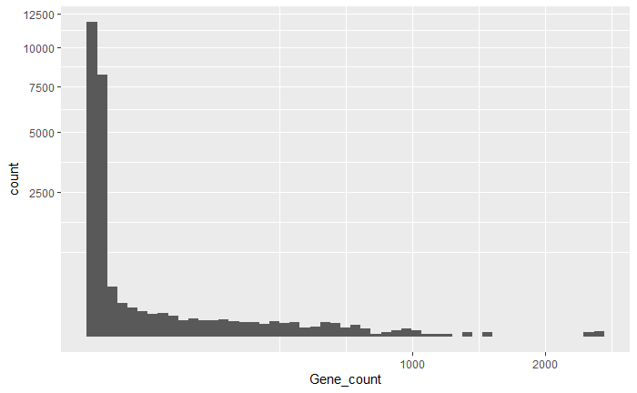

```r
ggplot(benchmark.annot, aes(x=Gene_count)) + geom_histogram(binwidth = 1) +
  scale_x_sqrt() + scale_y_sqrt()
```

```r
mean(benchmark.annot$Gene_count)
```

```
[1] 8.902519
```

```r
median(benchmark.annot$Gene_count)
```

```
[1] 0
```

```r
mean(benchmark.annot$Gene_count) + 2*sd(benchmark.annot$Gene_count)
```

```
[1] 152.9149
```

```r
mean(benchmark.annot$Gene_count) + 3*sd(benchmark.annot$Gene_count) -> gc.cap
gc.cap
```

```
[1] 224.9211
```

We may therefore consider:

```r
filter(benchmark.annot, Gene_count <= gc.cap) -> benchmark.annot.small
```

```r
mean(benchmark.annot.small$Gene_count)
```

```
[1] 2.492593
```

```r
median(benchmark.annot.small$Gene_count)
```

```
[1] 0
```

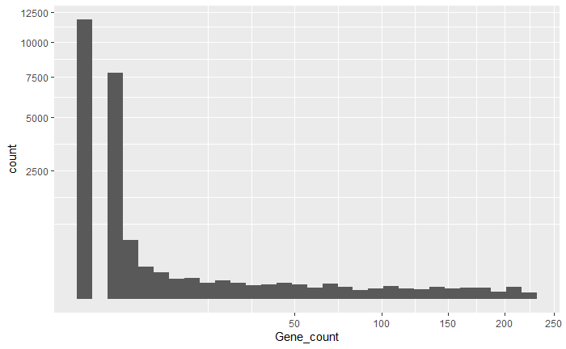

```r
ggplot(benchmark.annot.small, aes(x=Gene_count)) + geom_histogram() + scale_x_sqrt() + scale_y_sqrt()
```

# 3. Analysis

## 3-0. Clean-up for memory

```r
# from 1-1 Data import via vcfR
rm("delly.vcf"); rm("manta.vcf"); rm("melt.vcf"); rm("wham.vcf"); rm("svaba.vcf")
# from 2-1 Pseudo-BED workflow
rm("gr"); rm("simplebed"); rm("simplegr"); rm("vcf"); rm("delly.bed")
```

## 3-1. SV call location across NA12878 by different callers

### 3-1-1. (ORIGINAL) Using benchmark.master

```r
# remove non-readable chromosome entries in benchmark.master
filter(benchmark.master, CHROM %in% c("1", "2", "3", "4", "5", "6", "7", "8", "9", "10", "11", "12", "13", "14", "15", "16", "17", "18", "19", "20", "21", "22", "X")) -> benchmark.master

# fix x-axis ("CHROM") order
benchmark.master$CHROM <- factor(benchmark.master$CHROM, levels=unique(benchmark.master$CHROM))
table(benchmark.master$CHROM) ## checking up
```

```
< table of extent 0 >
```

[figure not shown]

```r
#sample_size = benchmark.master %>% group_by(CHROM) %>% summarize(num=n())

#benchmark.master %>%
  #left_join(sample_size) %>%
  #mutate(chrom = paste0(CHROM, "\n (n=", num, ")")) %>%

ggplot(benchmark.master, aes(x = CHROM, fill=Caller)) + # set x=chrom if want to include sample size, n (overlapping issue)
    geom_bar() + #scale_y_log10() +
    theme_bw() + theme(axis.text.x = element_text(angle = 60, vjust = 1, hjust = 1.2)) +
    labs(x="Chromosome", y="count") +
    ggtitle("SV location by caller in NA12878")
```

```r
#ggsave("SV_location_NA12878.png")
```

```r
# in VCF master file
filter(benchmark.master, CHROM == "chrY") %>%
  print()
```

| CHROM | POS | ID | REF | ALT | QUAL | FILTER | Caller |
| --- | --- | --- | --- | --- | --- | --- | --- |

```r
# in AnnotSV file
filter(benchmark.annot, SV_chrom == "chrY") %>%
  print()
```

| AnnotSV_ID | SV_chrom | SV_start | SV_end | SV_length | SV_type | Samples_ID | ID | REF | ALT | QUAL | FILTER | INFO | FORMAT | NA12878 | Annotation_mode | CytoBand | Gene_name | Gene_count | Tx | Tx_start | Tx_end | Overlapped_tx_length | Overlapped_CDS_length | Overlapped_CDS_percent | Frameshift | Exon_count | Location | Location2 | Dist_nearest_SS | … |
| --- | --- | --- | --- | --- | --- | --- | --- | --- | --- | --- | --- | --- | --- | --- | --- | --- | --- | --- | --- | --- | --- | --- | --- | --- | --- | --- | --- | --- | --- | --- |

Let’s say I don’t trust the results from the original benchmark.master file at all. Let’s repeat the plot:

### 3-1-2. (UPDATED) Using benchmark.annot

```r
#as.character(benchmark.annot$SV_chrom) -> benchmark.annot$SV_chrom
benchmark.annot$SV_chrom <- factor(benchmark.annot$SV_chrom, levels=c("1", "2", "3", "4", "5", "6", "7", "8", "9", "10", "11", "12", "13", "14", "15", "16", "17", "18", "19", "20", "21", "22", "X", "Y"))
table(benchmark.annot$SV_chrom)
```

```
   1    2    3    4    5    6    7    8    9   10   11   12   13   14   15   16   17   18   19   20   21   22    X    Y
1717 1631 1320 1298 1211 1345 1283  915  835 1119  969  950  890  595  508  614  618  534  724  700  322  331  777  108
```

[figure not shown]

```r
ggplot(benchmark.annot, aes(x = SV_chrom, fill=Caller)) +
    geom_bar() + #scale_y_log10() +
    theme_bw() + theme(axis.text.x = element_text(angle = 60, vjust = 1, hjust = 1.2)) +
    labs(x="Chromosome", y="count") +
    ggtitle("SV location by caller in NA12878, excluding SvABA, using AnnotSV")
ggsave("SV_location_NA12878_annotSV.png")
```

## 3-2. SV type by caller

### 3-2-1. (ORIGINAL) Using the GRIDSS workflow-derived pseudo-BED file

> NB: “SimpleEvents” containing only DEL, DUP, INS, INV.

```r
# fix x-axis ("SV_type") order
benchmark.bed$SV_type <- factor(benchmark.bed$SV_type, levels=unique(benchmark.bed$SV_type))
table(benchmark.bed$SV_type) ## checking up
```

### 3-2-2. (UPDATED) Using AnnotSV

> NB: Multiple SV classes as described by AnnotSV

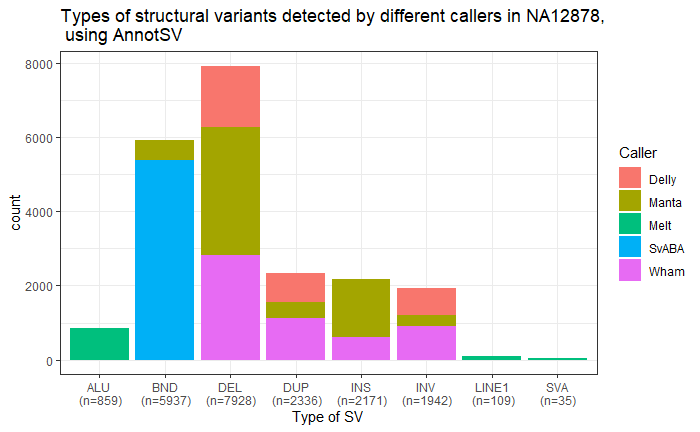

```r
sample_size = benchmark.annot %>% group_by(SV_type) %>% summarize(num=n())

benchmark.annot %>%
  left_join(sample_size) %>%
  mutate(svtype = paste0(SV_type, "\n (n=", num, ")")) %>%

ggplot(aes(x = svtype, fill=Caller)) +
    geom_bar() + #scale_y_log10() +
    theme_bw() +
    labs(x="Type of SV", y="count") +
    ggtitle("Types of structural variants detected by different callers in NA12878, \n using AnnotSV")
```

```r
rm("sample_size")
```

### 3-2-3. (NEW) Using maestro file

## 3-3. Number of variants detected by all methods

```r
table(as.factor(benchmark.bed$Caller))
```

We want to know: Are any of these calls made by multiple callers? We take the following approach.

- Original approach (1st edition):

> Count the start=start and end=end and if n=4 we know it’s been called by all four callers — *if there are no duplicates in each caller* — this can be weakly tested by if(n >= 5) {return “DUPLICATE”}.
- Updated approach (2nd edition):

> Let CI% == “a set standard (0.1%?)”, then define two given SV calls match if and only if,

```
  start_A %in% [start_std +- CI%] && end_A %in% [end_std +- CI%]
```

> … and we can use the original workflow to aggregate the Callers for same SV calls (as defined above).

### 3-3-1. Original approach: Aggregate master AnnotSV file using strict start=start, end=end approach

```r
## count number of same calls | no dup for each caller
same.sv.count <- benchmark.bed %>%
                    #aggregate(.[7], .[-7], FUN = function(X) paste(unique(X), collapse=", ")) %>%
                      group_by(start, end) %>% summarise( n=n() )

ggplot(same.sv.count, aes(x=n)) +
    geom_bar() +
    theme_bw() + xlab("Number of callers calling the same calls in NA12878")

ggsave("Multiple_calls_count.png")
```

```r
# QC
length(unique(same.sv.count$start)) == nrow(same.sv.count)
length(unique(same.sv.count$end)) == nrow(same.sv.count)
length(unique(same.sv.count$start)) == length(unique(same.sv.count$end))
```

```r
# QC
# this address is purportedly to contain 3 Calls
filter(benchmark.bed, start==26001844 & end==26002386) %>%
  view() # unique callers or 3 suplicates, etc?
```

QC seems to pass. Conclusion: No single SV were called by all callers in this data set.

Or is it…

```r
# double-checking our results using AnnotSV files
subset(benchmark.annot, select = c("SV_start", "SV_end", "SV_type", "ID", "Caller")) -> cant.pipe

aggregate(cant.pipe[5], cant.pipe[-5], unique) -> place.holder

place.holder$ID <- NULL

aggregate(place.holder[4], place.holder[-4], FUN = function(X) paste(unique(X), collapse=", ")) -> common.variants

# checking callers power set distribution
table(as.factor(common.variants$Caller))
```

```
       Delly Delly, Manta        Manta         Melt        SvABA SvABA, Manta         Wham
        3163            2         6199         1003         5249           52         5489
```

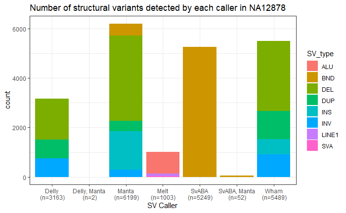

```r
# plot
sample_size = common.variants %>% group_by(Caller) %>% summarize(num=n())

common.variants %>%
  left_join(sample_size) %>%
  mutate(caller = paste0(Caller, "\n (n=", num, ")")) %>%

ggplot(aes(x = caller, fill=SV_type)) +
    geom_bar() +
    theme_bw() +
    labs(x="SV Caller", y="count") +
    ggtitle("Number of structural variants detected by each caller in NA12878")
```

```r
rm("sample_size")
rm("cant.pipe")
rm("place.holder")
```

Explain the discrepancy.

### 3-3-2. (UPDATED) Aggregating caller set in master file using relaxed SV matching criteria

The idea is to: - 1. Form a smaller subset from annotated master file first — this contains SV location, and basic profile such as caller used, SV type, ACMG class, and gene topology.

```
- 2. From this subset: For any two calls (made by different callers, suppose there are no duplicates, including multiple split annotations for one SV), if:

    df.subset %>%

        SV_start_A between() SV_start_B +- 0.02*SV_start_B &&
        SV_end_A between() SV_end_B +- 0.02*SV_end_B
    then return TRUE --> aggregate the two rows by "Caller", delimiter = ','
  ...and repeat this process for all entries. Send new data frame back to the original subset.
```

In the resultant df, we should expect:

```
  Calls considered the same call are grouped into one entry, with $Caller == all callers that called this SV
```

i.e.,

```
 | start        | end           | ... other variables ... | Caller                      |
 |:------------:|---------------|:-----------------------:|----------------------------:|
 | 53218-20     | 53421-24      | ...                     | Delly, Manta                |
 | 61385        | 63267         | ...                     | Delly                       |
 | ...          | ...           | ...                     | ...                         |
```

One way to do this is to group start:end into one column, designated “SV_range”: …

(see package “data.table”)

## 3-4. ACMG class of variants

```r
# first, see the distribution of ACMG class in annotated data
table(as.factor(benchmark.annot$ACMG_class))
```

```
   1    3    4    5
3721 6328   13  202
```

The following is for Annotation_mode including “split” during AnnotSV.

```r
# cleaning calls of NA pathogenicity class
filter(benchmark.annot, ACMG_class != "full=NA") -> benchmark.ACMG

# joining full and split mode calls
# by directly forcing "full=x" -> 'x'
benchmark.ACMG[benchmark.ACMG == "full=1"] <- "1"
benchmark.ACMG[benchmark.ACMG == "full=3"] <- "3"
benchmark.ACMG[benchmark.ACMG == "full=4"] <- "4"
benchmark.ACMG[benchmark.ACMG == "full=5"] <- "5"
```

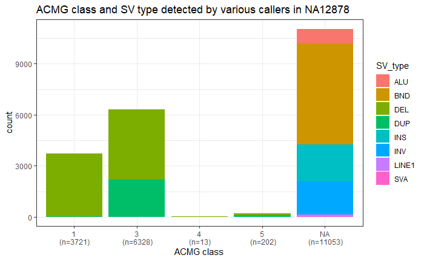

```r
sample_size = benchmark.annot %>% group_by(ACMG_class) %>% summarize(num=n())

benchmark.annot %>%
  left_join(sample_size) %>%
  mutate(ACMG.class = paste0(ACMG_class, "\n (n=", num, ")")) %>%

ggplot(aes(x = ACMG.class, fill=SV_type)) + # can try fill=Caller next
    geom_bar() +
    theme_bw() +
    labs(x="ACMG class", y="count") +
    ggtitle("ACMG class and SV type detected by various callers in NA12878")

ggsave("ACMG_NA12878_annot.png")
```

```r
rm("sample_size")
```

Is this graph trust-worthy? Why?

```r
length(benchmark.ACMG$ACMG_class) == length(benchmark.bed)
length(benchmark.ACMG$ACMG_class) == length(benchmark.master)
```

Explain the discrepancy.

## 3-5. Detected variants affecting CDS

```r
table(as.factor(benchmark.annot$Location2))
```

### 3-5-1. CDS-affecting SVs

### 3-5-2. The elite list

<1st layer: AnnotSV input level>

```
Raw call set %>% filter(PASS) %>% filter(ACMG = {4,5}) %>%
```

<2nd layer:>

```
      filter(Called by e.g. at least 3 callers out of 5 used) %>% filter(CDS-affecting) %>% filter(Known to affect XX tissue)
```

Further refinement: